# Wprowadzenie do programowania w R

Podstawy programowania w R

04 październik, 2018

**Mateusz Rzeszutek**

**AGH** Akademia Górniczo-Hutnicza im. Stanisława Staszica w Krakowie, Wydział Geodezji Górniczej i Inżynierii Środowiska, Katedra Kształtowania i Ochrony Środowiska.

**e-mail:** *rzeszut@agh.edu.pl*.

**lokalizacja:** bud. C-4, p. V, pok. 511, al. A. Mickiewicza 30, Kraków, Polska.

**konsultacje:** Zgodnie z informacjami na stronie [dziekantu](https://dziekanat.geod.agh.edu.pl/dziekanat/index.php?menu1=4&menu2=17&co=o&lin=o&wiad=@f_konsult_prez) lub po uzgodnieniu za pośrednictwem e-mail.

[figure not shown]

# 1. Wprowadzenie

Potrafisz już założyć nowy projekt w `RStudio`, instalować pakiety oraz wiesz gdzie i jak szukać informacji o `R`. Najwyższy czas zacząć pracę z `R`. W ramach tematu *Podstawy programowania w R* nauczysz się:

1. jak wykonywać obliczenia,
2. jak pracować z różnego typu danymi,
3. jak tworzyć obiekty,
4. tworzyć zmienne,
5. indeksować obiekty,
6. wykonywać operacje algebraiczne i logiczne na obiektach,
7. oraz wczytywać i zapisywać dane.

Zanim zaczniesz, otwórz projekt `RStudio`, który utworzyłeś na ostatnich zajęciach. Jeśli go nie masz przy sobie to utwórz nowy. Najlepszym rozwiązaniem jest zakąłdanie projektu w rozpakowynm folderze, który pobrałeś z upel.

Bezpiecznym rozwiązaniem jest zapisywać projekt na nośniku zewnętrznym (pendrive, dysk przenośny). Natomiast z doświadczenia wiem, że czasem zdarza się zapomnieć wziąć go ze sobą. W związku z tym możesz stworzyć kopie na dysku google lub innej darmowej usłudze do przechowywania i synchronizacji plików. To drugie rozwiazanie jest bezpieczne, ale wymaga ciągłego kopiowania.

# 2. R jako kalkulator

## 2.1 Podstawowe operacje arytmetyczne

Program R może służyć jako kalkulator matematyczny. Zaczniemy od wykonania kilku prostych działań. W tym ćwiczeniu zachęcam do bezpośredniej pracy z `konsolą R` z pominięciem okna skryptów.

Najpierw poznamy podstawowe operatory arytmetyczne:

Tabela 1. Zestawienie operatorów arytmetycznych stosowanych w R

| Operator | opis |
| --- | --- |
| - | Odejmowanie |
| + | Dodawanie |
| * | Mnożenie (iloczyn) |
| / | Dzielenie (iloraz) |
| ^ lub ** | Potęgowanie |
| %% | Reszta z dzielenia |
| %/% | Część całkowita z dzielenia |

Znajac już operatory Wykonaj poniższe podstawowe polecenia w konsoli R i sprawdź jakie otrzymasz odpowiedzi:

```r
2+2
2^2
4^2
1/10
(3+7)^(4-2)
8%%3
8%/%3
```

Po wpisaniu polecenia należy nacisnąć Enter w celu uruchomienia wykonania operacji obliczeniowej. Wynik wyświetli się w oknie.

Uwaga !!! W przypadku gdy polecenie nie zostało ukończone, a wcisnąłeś Enter, konsola poprosi Cię o dokończenie polecenie poprzez wyświetlenie znaku +. np.:

```r
## wpisz
2+
## wciśnij enter
## wyświetli się znak plusa +
## wpisz 2
2
## naciśnij enter i zobacz co się stało.
```

Ten problem pojawia się dość często, gdy mamy wiele nawiasów. Zdarza się któryś z nich pominąć, gdy jest ich bardzo dużo. W `R` można wykonywać wiele poleceń w jednej lini kodu. Do tego celu służy średnik: `;`, który rozdziela polecenia.

```r
2+2 ; 2+5 ; 9^2 ; "itd..."
```

```
## [1] 4
```

```
## [1] 7
```

```
## [1] 81
```

```
## [1] "itd..."
```

##### Ćwiczenie 1

###### Treść

Które operatory arytmetyczne mają pierwszeństwo

- mnożenie, czy dzielenie?
- mnozenie, czy dodowanie?
- potęgowanie, czy dzielenie?
- dzielenie, czy dodwanie?

###### Odp.

Nawias wymusza pierwszeństwo. Przykłady móWią same za siebie.

```r
10/5*2  ; (10/5)*2 ; 10/(5*2)
```

```
## [1] 4
```

```
## [1] 4
```

```
## [1] 1
```

```r
2*2+100 ; 2*(2+100)
```

```
## [1] 104
```

```
## [1] 204
```

```r
4^2/2  ; 4^(2/2)
```

```
## [1] 8
```

```
## [1] 4
```

```r
2/2+2 ; (2+2)/2
```

```
## [1] 3
```

```
## [1] 2
```

## 2.2. Funkcje arytmetyczne

Wspominaliśmy, żę R ma wbudowanych kilka pakietów podstawowych. W pakiecie `base` jest szereg podstawowych funkcji stosowanych na co dzień podczas korzystania z programu R. Pełną listę funkcji dostępnych w pakiecie base wywołać można poleceniem:

```r
?base
library(help = "base")
```

Pakiet ten zawiera bardzo dużo funkcji. Pozwalają one na wykonywanie operacji arytmetycznych m.in. na pojedynczych liczbach. Poniższa tabela przedstawia zestawienie wybranych funkcji wraz z opisem.

Tabela 2. Zestawienie wybranych funkcji pakietu base

| Funkcja | Opis funkcji |
| --- | --- |
| round(x) | Liczba całkowita najbliższa wartości x |
| signif(x,k) | Wartość x zaokrąglona do k miejsc znaczących |
| floor(x) | Podłoga, czyli największa liczba całkowita nie większa od x |
| ceiling(x) | Sufit, czyli najmniejsza liczba całkowita nie mniejsza od x |
| trunc(x) | Wartość x po odcięciu części rzeczywistej, dla liczb dodatnich działa jak floor(), dla ujemnych jak ceiling |
| abs(x) | Wartość bezwzględna z x |
| log(x) | Logarytm naturalny z x |
| log(x, base) | Logarytm o podstawie base z x |
| log10(x) | Logarytm o podstawie 10 z x |
| log2(x) | Logarytm o podstawie 2 z x |
| exp(x) | Funkcja wykładnicza (eksponenta) z x |
| expm1(x) | Funkcja równoważna wyrażeniu exp(x)-1, ale wyznaczona z większą dokładnością dla x\|«1\| |
| log1p(x) | Funkcja równoważna wyrażeniu log(1+x), ale wyznaczona z większą dokładnością dla x\|«1\| |
| sqrt(x) | Pierwiastek kwadratowy z x, równoważne poleceniu x^0.5 |

W ramach ćwiczenia Wykonaj poniższe operacje.

```r
round(2.5)         ; round(2.51)
signif(1.22562, 4) ; signif(1.22562, 2)
floor(23.45)       ; floor(23.75)
ceiling(23.45)     ; ceiling(23.57)
trunc(23.25)       ; trunc(23.89)
abs(-54.2) ; abs(54.2)
log(10)    ; log(1)
log(10,10) ; log10(10)
log(100)   ; exp(5)
exp(0)     ; exp(1)
sqrt(4)    ; sqrt(36)
```

**Uwaga !!!** Separatorem miejsc dziesiętnych jest kropka. Separator miejsca dziesiętnego można ustawić w:

- Panel sterowania / Zegar, język i region / region /
- Zakładka format, wybierz ustawienia dodatkowe
- W oknie symbol dziesiętny wprowadź kropkę (.) zamiast przecinka (,)

Zauważ, że funkcja może przyjmować więcej niż jeden argument. W większości przypadków wprowadzaliśmy jedną wartość liczbą, a w niektórych dwie wartości. Przyjrzymy się więc pomocy funkcji `round()`

```r
?round
```

Zauważ, że funkcja ta może przyjmować dwa argumenty:

- `x` - liczba lub wektor,
- `digits` - liczba miejsc po separatorze miejsc dziesiętnych.

Wykonjamy teraz dwa polecenia stosując nazwy argumentów i zakładając, że chcemy zaokrąglić liczbę 2.2545, odpowiednio do liczby całkowitej oraz 1, 3, 4 miejsca po przecinku.

```r
round(x = 2.2545) ; round(x = 2.2545, digits = 1)
```

```
## [1] 2
```

```
## [1] 2.3
```

```r
round(2.2545, 3) ; round(2.2545, 4)
```

```
## [1] 2.255
```

```
## [1] 2.2545
```

Przyglądnij się, jak funkcja `round()` gdy zaokrągla wartości liczbowe, zwróć uwagę na wartość oznaczającą połowę (5). Spróbuj odpowiedzieć na pytanie jaka jest zasada zaokrąglania.

##### Ćwiczenie 2

###### Treść

Wykonaj następujące polecenia:

- Oblicz pierwiastek 4 stopnia z liczby 16.
- Zaokrągl liczbę 1.23446789, do 3 miesjca po przecinku.
- Wyznacz wartość bezwzględną liczby -23.
- Oblicz pierwiastek i logarytm dziesiętny z liczby 100 w jednej linii poleceń.
- Oblicz logarytm dziesiętny z 1000 stosując dwie różne funkcje, w jednej linii poleceń.

###### Odp.

```r
16^(1/4)
```

```
## [1] 2
```

```r
round(1.23446789, 3) # działa dobrze ?
```

```
## [1] 1.234
```

```r
abs(-23)
```

```
## [1] 23
```

```r
sqrt(100) ; log10(100)
```

```
## [1] 10
```

```
## [1] 2
```

```r
log(1000, 10) ; log10(1000)
```

```
## [1] 3
```

```
## [1] 3
```

## 2.3. Funkcje trygonometryczne

Funkcje trygonometryczne operują na argumentach podanych w radianach, a nie stopniach. Chcąc przeliczyć stopnie na radiany można skorzystać z wzoru: $rad = \alpha * \frac{\pi}{180}$. Gdyby ktoś nie wiedział co to radian to zapraszam na stronę [WWW](http://home.agh.edu.pl/~rudnicki/Cw1/radian.htm)

Zestawienie funkcji trygonometrycznych:

Tabela 3. Zestawienie funkcji trygonometrycznych

[output not shown]

W celu przeliczania stopni na radiany można również wykorzystać funkcje `rad()`, ale wymaga to instalacji pakietu `circular`.

W ramach przypomnienia podstaw matematyki, wykres funkcji:
$$y = cos(x)$$
$$y = sin(x)$$

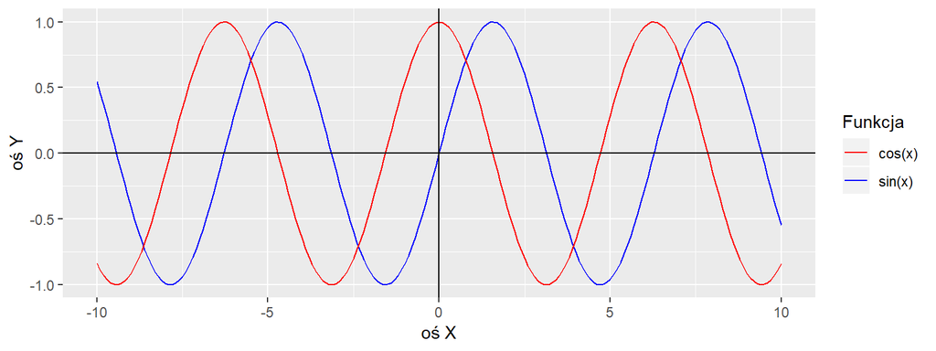

##### Ćwiczenie 3

###### Treść

Wykonaj następujące polecenia:

1. Oblicz sinus, cosinus, arcus tanges, arcus sinus kątów 0°, 30°, 45°, 90°, 180°, 360°
2. Przelicz współrzędne (x,y) (0,1); (1,1); (1,0); (1,-1); (0,-1); (-1,-1); (-1,0); (-1,1) na biegunowe. Wyznacz kąt (alfa) w stopniach oraz odległość (r) względem punktu 0.0.

###### Odp.

**Rozwiązanie zadania pierwszego.**

Tabela 4. Wyniki działań funkcji sinus, cosinus, arcus tanges, arcus sinus kątów dla katów 0°, 30°, 45°, 90°, 180°, 360°

|  | rad | sin | cos | atan | asin |
| --- | --- | --- | --- | --- | --- |
| 1 | 0.000 | 0.000 | 1.000 | 0.000 | 0.000 |
| 2 | 0.524 | 0.500 | 0.866 | 0.482 | 0.551 |
| 3 | 0.785 | 0.707 | 0.707 | 0.666 | 0.903 |
| 4 | 1.571 | 1.000 | 0.000 | 1.004 | NA |
| 5 | 3.142 | 0.000 | -1.000 | 1.263 | NA |
| 6 | 6.283 | 0.000 | 1.000 | 1.413 | NA |

> Dlaczego funkcja `asin(x)` zwraca wartości `NaN`.

**Rozwiązanie zadania drugiego.**

Tabela 5. Wartości współrzędnych x,y w układzie biegunowycm alfa, r

| x | y | r | alpha | theta |
| --- | --- | --- | --- | --- |
| 0 | 1 | 1.000000 | 90 | 1.5707963 |
| 1 | 1 | 1.414214 | 45 | 0.7853982 |
| 1 | 0 | 1.000000 | 0 | 0.0000000 |
| 1 | -1 | 1.414214 | 315 | 5.4977871 |
| 0 | -1 | 1.000000 | 270 | 4.7123890 |
| -1 | -1 | 1.414214 | 225 | 3.9269908 |
| -1 | 0 | 1.000000 | 180 | 3.1415927 |
| -1 | 1 | 1.414214 | 135 | 2.3561945 |

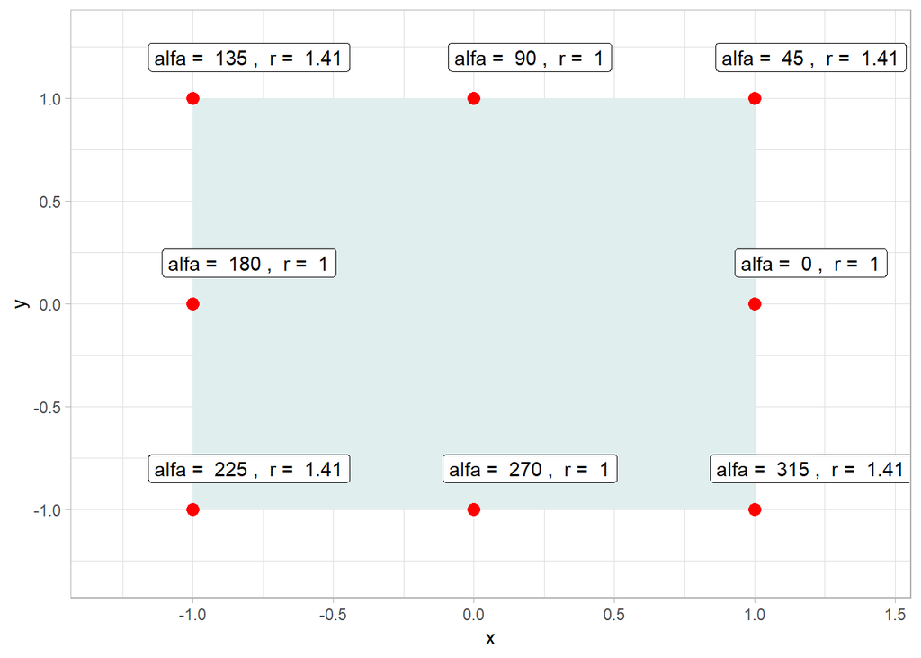

Rys. 2. Wykres współrzędnych, wraz z wartościami katą alfa i odeleglości od punktu 0.0

## 2.4 Operatory logiczne i relacyjne

Ostatnim elementem tego rozdziału jest zrozumieniu operacji logicznych oraz relacyjnych, których wynikiem jest wartość logiczna. W R występują dwa rodzaje wartości logicznych `TRUE` i `FALSE`. Wykonywać możemy na nich operacje:

Tabela 6. Operatory i funkcje logiczne

| Operacja | Znaczenie |
| --- | --- |
| !x | negacja |
| x \| y | alternatywa |
| x & y | koniunkcja |

Zerknij również do pomocy `?Logic`.

Teraz wykonamy kilka operacji, które lepiej pozwolą ci zrozumieć działanie tych operacji

```r
!FALSE # negacja
!TRUE # negacja
FALSE | FALSE # alternatywa
TRUE  | TRUE # alternatywa
TRUE  | FALSE # alternatywa
FALSE & FALSE # koniunkcja
TRUE  & TRUE # koniunkcja
TRUE  & FALSE # koniunkcja
```

Wartość logiczna jest róWnież zwracana przez R, gdy stosujemy operatory logiczne.

Tabela 7. Operatory relacyjne

| Operacja | Znaczenie |
| --- | --- |
| x < y | czy mniejszy? |
| x > y | czy większy? |
| x <= y | czy nie większy? |
| x >= y | czy nie mniejszy? |
| x == y | czy równy? |
| x != y | czy nie równy |

Zerknij również do pomocy `?Comparison`.

Wykonaj Kilka przykładów:

```r
1 > 3
3 >= 3
5 == 5
5 != 5
5 == 5 & 5 != 5
5 == 5 | 5 != 5
```

# 3. Obiekty i typy danych

Każdy język programowania można postrzegać jako narzędzie służące do instruowania komputera, w jaki sposób należy przkształcić dane wejściowe, aby otrzymać interesujące dane wyjściowe (Gagolewski 2014). W celu efektywnego korzystania z języka programowania musimy poznać obiekty stosowane w języku programowania `R`. Najważniejszymi obiektami stosowanymi w `R` są:

1. Wektory, `(vector)`.
2. Listy, `(list)`.
3. Macierze, `(matrix)`.
4. Tablice, często zwane ramkami danych, `(data.frame)`.
5. Funkcje, `(function)`.

1. Liczbowy `(numeric)`, który dzielimy na liczby całkowite `(integer)` i liczby rzeczywiste `(double)`.
2. Znakowy `(character)`, w postaci ciągu znaków.
3. Czynnikowy `(factor)` lub wyliczeniowy, kategoryczny, służy do grupowania danych.
4. Logiczny `(logical)`, przechowyjący informacje w postaci `TRUE` i `FALSE`.
5. Daty `(as.POSIXct)`.

Więcej informacji na temat podstawowych i złożonych typów danych języka R znajdziecie w Gagolewski (2014)

Własnosćiasności obiektu w języku R możemy sprawdzać, za pomocą kilku funkcji:

Tabela 2. Zestawienie wybranych funkcji zwracającyh informacje o własnosćiasnościach obiektu

| Funkcja | Opis funkcji |
| --- | --- |
| class() | klasa, typ obiektu |
| typeof() | typ obiektu |
| length() | długość obiektu |
| attributes() | atrybuty obiektu |
| attr() | dostęp do atrybutów obiektu |
| object.size() | wielkość obiektu w bajtach |
| mode() | wewnętrzna reprezentacja obiektu |
| str() | szczegóły wewnętrznej reprezentacji obiektu |

**Postaraj się zapamiętać:** `str(), class(), lenght(), typeof()` - będziemy z nich często korzystać.

## 3.1. Zmienna

Zanim przejdziemy do pracy z poszczególnymi obiektami w `R`, postaram się przybliżyć wam pojęcie **zmiennej** w `R`. Zmienne przechowują wprowadzane dane. np.: liczby, tekst, wektory liczb, wektor elementów tekstowych itd. Mogą również przechowywać informację o wynikach operacji arytmetycznych. Zmienne mogą w zasadzie przechowywać wszystkie dostępne typy obiektów, które zostaną omówione szerzej w kolejnych podrozdziałach. Aby przypisać zmiennej wartość należy zastosować operator. Tym operatorem jest znak przekazania wartości (<-), (->), (=). Pierwsze dwa operatory są operatorami nadrzędnymi względem operatora znaku równości.

Wykonajmy kilka przykładów. Wykonując poniższe polecenia zwróć uwagę na zakładkę `environmental` w prawym górnym oknie programu RStudio.

```r
a = 2      ## definiujemy zmienną a
b = 3      ## definiujemy zmienną b
a          ## wyświetla wartość zmiennej a
b          ## wyświetla wartość zmiennej b
a+b        ## zwraca wyniki dodawania zmiennych
d <- a+b   ## zapisuje winik pod zmiennej d
d          ## wyświetla wartość zmiennej d
```

Kilka bardziej złożony przykładów:

```r
27+abs(-12.4)*(1/2)^exp(2)-100 * sqrt(0.3)
d <- 27+abs(-12.4)*(1/2)^exp(2)-100 * sqrt(0.3)
d
z <-c/(a*2)+10^b
z
```

Teraz, kilka przykładów z trochę innej beczki:

```r
nazwa <- "nazwa"
logiczny <- "TRUE"
inny <- "5"
calko1 <- 5
calko2 <- 5L
rzecz <- 3.876
nic <- NA
pusty <- NULL
```

**WAŻNE !!!** Operator przekazania wartości do zmiennej można utworzyć przy pomocy skrótu klawiszy **alt+myślnik**, czyli **(alt+-)**.

**WAŻNE !!!** Jeśli chcemy, aby zawartość zmiennej została wyświetlona w ekranie konsoli od razu po jej utworzeniu, musimy polecenie zamknąć w nawiasach okrągłych `(polecenie)`, np.:

```r
(z <- 23)
```

## 3.2. Wektor

Wektor to uporządkowany zbiór obiektów tego samego typu. Do tworzenia wektora z pojedynczych elementów lub innych wektorów służy funkcja `c()`. W programie `R` nie ma rozróżnienia na pojedynczą wartość i wektor, pojedyncze wartości traktowane są jako jednoelementowe wektory.

Utworzymy pierwszy 4 - elemetowy wektor liczbowy.

```r
a <- c(1,2,3,4) ; a
```

```
## [1] 1 2 3 4
```

Wektory w postaci sekwencji możemy tworzyć przy pomocy operatora tworzenia ciągów arytmetycznych `:`, np:

```r
a <- 1:4 ; a
```

```
## [1] 1 2 3 4
```

Wektor może przechowywać każdy typ danych. Poniżej kilka przykłądów skłądających się z 3 poleceń, tworzenia, wyświetlania i sprawdzenia typu obiektu:

```r
a <- c(1L, 2L: 3L, 4L) ; a  ; typeof(a)
```

```
## [1] 1 2 3 4
```

```
## [1] "integer"
```

```r
a1 <- 1:4 ; a1 ; typeof(a1)
```

```
## [1] 1 2 3 4
```

```
## [1] "integer"
```

```r
a2 <- 1.1:4.1 ; a2 ; typeof(a2)
```

```
## [1] 1.1 2.1 3.1 4.1
```

```
## [1] "double"
```

W tym przypadku musimy zwrócić uwagę, że utworzone wektory `a`, `a1` i `a2` są typu `intiger` i `double`, ale wrzystkie są zaliczane do `numeric`.

Wpisując liczby dozwolona jest notacja naukowa (np. 2.5e3 oznacza 2500). Separatorem miejsca dziesiętnego w programie R jest kropka. Wyróżnioną wartością jest `NaN` (to skrót rozwijający się w *ang. not a number*, czyli „nie liczba”). Ta wartość może pojawić się w wyniku wykonania niepoprawnego działania (np. próby logarytmowania liczby ujemnej). Literały `Inf` i `-Inf` oznaczają plus i minus nieskończoność.

```r
a <- c(2.5e3, 1.1e2, NaN, Inf, -Inf) ; a ; class(a) ; typeof(a)
```

```
## [1] 2500  110  NaN  Inf -Inf
```

```
## [1] "numeric"
```

```
## [1] "double"
```

Teraz utworzymy wektory wartości logicznych i znakowych

```r
a  <- c("a","b","b", "c")  ; a  ; typeof(a)
```

```
## [1] "a" "b" "b" "c"
```

```
## [1] "character"
```

```r
a1 <- c(TRUE, FALSE, T, F) ; a1 ; typeof(a1)
```

```
## [1]  TRUE FALSE  TRUE FALSE
```

```
## [1] "logical"
```

**UWAGA !!!** Zauważ, że nadpisaliśmy zmienną `a` i `a1`.

Wektory atomowe w R mogą przechowywać elementy jednego typu, natomiast często w wyniku w wektorze mogą pojawić się elementy innego typu. Wykonaj poniższe przykłady i odpowiedz na pytanie jaka jest hierarchia typów obiektów w R.

```r
a1 <- c(F, 1L, 2.2, "cztery") ; typeof(a1)
```

```
## [1] "character"
```

```r
a2 <- c(F, 1L, 2.2) ; typeof(a2)
```

```
## [1] "double"
```

```r
a3 <- c(F, 1L) ; typeof(a3)
```

```
## [1] "integer"
```

Z godnie z powyższymi przykłądami, nie trudo zauważyć, że R nadaje typ obiektu w sposób, który umożliwia minimalizację strat informacji. Taki mechanizm nazywamy `uzgodnieniem typów`. Ta wiedza, będzie bardzo przydatna w trakcie wczytywania danych do programu R z plików zewnętrznych np. tekstowych.

Należy zwrócić uwagę, że wartość `F` jest interpretowana przez program R jako `0`, natomiast `T` jako `1`.

```r
(2==2)+3
```

```
## [1] 4
```

```r
(2>3)+1
```

```
## [1] 1
```

Spodziewałeś się takiego wyniku ?.

```r
TRUE + 3
```

```
## [1] 4
```

```r
FALSE + 1
```

```
## [1] 1
```

Domyślny typ obiektu możemy zmienić. Korzystaj z funkcji zaczynającej się od `as.` i nazwy typu obiektu. Poniżej kilka przykłądów konwersji typu danych.

```r
a <- 1:4 ; a
typeof(a)
typeof(as.double(a)) # funkcja w funkcji

a <- 1.1:4.1 ; a
typeof(a)
typeof(as.integer(a)) # zwraca wynik funkcji zewnętrznej

a <- c(TRUE, FALSE, TRUE) ; a
typeof(a)
typeof(as.character(a))

a <- c(1,0,1,1,1,0) ; a
typeof(a)
typeof(as.logical(a))
```

Nalezy pamiętać, że stosowanie funkcji np `as.logical(a)` spowoduje, że na ekranie konsoli wyświetlą się przekonwertowane wartości wektora, ale typ obiektu `a` nie ulegnie zmianie. Zawsze trzeba nadpisywać obiekt. Wykonaj i przeanalizuj poniższy przykład.

```r
a <- c(1L,0L,1L,1L,1L,0L) # tworzymy wektor typu integer
a             # wyświetlamy obiekt na ekranie konsoli
```

```
## [1] 1 0 1 1 1 0
```

```r
as.logical(a) # konwersja 0 = FALSE, 1 = TRUE
```

```
## [1]  TRUE FALSE  TRUE  TRUE  TRUE FALSE
```

```r
typeof(a)     # sprawdzamy
```

```
## [1] "integer"
```

```r
# teraz poprawna składnia
a <- c(1L,0L,1L,1L,1L,0L)
a <- as.logical(a) # konwersja z nadpisaniem
a
```

```
## [1]  TRUE FALSE  TRUE  TRUE  TRUE FALSE
```

```r
typeof(a) # sprawdzamy
```

```
## [1] "logical"
```

Odwrócimy operacje konwersji:

```r
as.numeric(a)
```

```
## [1] 1 0 1 1 1 0
```

```r
as.integer(a)
```

```
## [1] 1 0 1 1 1 0
```

```r
as.double(a)
```

```
## [1] 1 0 1 1 1 0
```